# Table of Contents

## ЗАДАНИЕ 1-2

### Импорт библиотек

```python
import pandas as pd
import seaborn as sns

sns.set(rc={'figure.figsize':(10,12)})
```

### Чтение файла

```python
df = pd.read_csv('Заказы - Лист1.csv')
```

```python
# Валидация данных
```

```python
df.head()
```

|  | pay_date | producttitle | productType | revenue | paymenttype | Source | user_type |
| --- | --- | --- | --- | --- | --- | --- | --- |
| 0 | 02.04.2022 | Продукт 1 | Тип 1 | 1530 | покупка | None | old |
| 1 | 02.04.2022 | Продукт 4 | Тип 1 | 3315 | покупка | Ютуб | new |
| 2 | 02.04.2022 | Продукт 6 | Тип 2 | 7170 | покупка | None | old |
| 3 | 02.04.2022 | Продукт 7 | Тип 3 | 12000 | в подарок | None | new |
| 4 | 02.04.2022 | Продукт 8 | Тип 3 | 12800 | в подарок | None | new |

```python
df.info()
```

```
<class 'pandas.core.frame.DataFrame'>
RangeIndex: 1671 entries, 0 to 1670
Data columns (total 7 columns):
 #   Column        Non-Null Count  Dtype
---  ------        --------------  -----
 0   pay_date      1671 non-null   object
 1   producttitle  1671 non-null   object
 2   productType   1671 non-null   object
 3   revenue       1671 non-null   int64
 4   paymenttype   1671 non-null   object
 5   Source        1671 non-null   object
 6   user_type     1671 non-null   object
dtypes: int64(1), object(6)
memory usage: 91.5+ KB
```

- пропуски отсутствуют
- в столбце pay_date тип данных object, сменим на datetime
- типы данных в остальных столбцах соответствуют своей сущности

```python
# Посмотрим на уникальные значения в каждом столбце
for col in df.columns:
    print(f'Тип данных {col}: \n{df[col].dtype}')
    print(f'Уникальные значения в столбце {col}: \n{df[col].sort_values().unique()}')
    print()
```

```
Тип данных pay_date:
object
Уникальные значения в столбце pay_date:
['02.04.2022' '03.04.2022' '04.04.2022' '05.04.2022' '06.04.2022'
 '07.04.2022' '08.04.2022' '09.04.2022' '10.04.2022' '11.04.2022'
 '12.04.2022' '13.04.2022' '14.04.2022' '15.04.2022' '16.04.2022'
 '17.04.2022' '18.04.2022' '19.04.2022' '20.04.2022' '21.04.2022'
 '22.04.2022' '23.04.2022' '24.04.2022' '25.04.2022' '26.04.2022'
 '27.04.2022' '28.04.2022' '29.04.2022' '30.04.2022']

Тип данных producttitle:
object
Уникальные значения в столбце producttitle:
['Продукт 1' 'Продукт 10' 'Продукт 11' 'Продукт 12' 'Продукт 13'
 'Продукт 14' 'Продукт 15' 'Продукт 16' 'Продукт 17' 'Продукт 18'
 'Продукт 19' 'Продукт 2' 'Продукт 20' 'Продукт 21' 'Продукт 22'
 'Продукт 23' 'Продукт 24' 'Продукт 25' 'Продукт 26' 'Продукт 27'
 'Продукт 28' 'Продукт 29' 'Продукт 3' 'Продукт 30' 'Продукт 31'
 'Продукт 32' 'Продукт 33' 'Продукт 34' 'Продукт 35' 'Продукт 36'
 'Продукт 37' 'Продукт 38' 'Продукт 39' 'Продукт 4' 'Продукт 40'
 'Продукт 41' 'Продукт 42' 'Продукт 43' 'Продукт 44' 'Продукт 45'
 'Продукт 46' 'Продукт 47' 'Продукт 48' 'Продукт 49' 'Продукт 5'
 'Продукт 50' 'Продукт 51' 'Продукт 52' 'Продукт 53' 'Продукт 54'
 'Продукт 55' 'Продукт 56' 'Продукт 57' 'Продукт 58' 'Продукт 59'
 'Продукт 6' 'Продукт 60' 'Продукт 61' 'Продукт 62' 'Продукт 63'
 'Продукт 64' 'Продукт 65' 'Продукт 66' 'Продукт 67' 'Продукт 68'
 'Продукт 69' 'Продукт 7' 'Продукт 70' 'Продукт 71' 'Продукт 72'
 'Продукт 73' 'Продукт 74' 'Продукт 75' 'Продукт 76' 'Продукт 77'
 'Продукт 78' 'Продукт 79' 'Продукт 8' 'Продукт 80' 'Продукт 81'
 'Продукт 9']

Тип данных productType:
object
Уникальные значения в столбце productType:
['Тип 1' 'Тип 2' 'Тип 3' 'Тип 4' 'Тип 5' 'Тип 6' 'Тип 7' 'Тип 8' 'Тип 9']

Тип данных revenue:
int64
Уникальные значения в столбце revenue:
[   36    50    67    80    84    90    97   100   108   110   160   170
```

[output cut: 36 more lines]

```

Тип данных paymenttype:
object
Уникальные значения в столбце paymenttype:
['в подарок' 'покупка']

Тип данных Source:
object
Уникальные значения в столбце Source:
['None' 'Блогер' 'Закрытые чаты в ТГ' 'Лидген' 'Реклама' 'Телеграм' 'Ютуб']

Тип данных user_type:
object
Уникальные значения в столбце user_type:
['new' 'old']
```

```python
print(f'источник под названием None, он составляет {round(100*(len(df[df["Source"]=="None"])/len(df)),2)}% всего датасета')
```

```
источник под названием None, он составляет 60.32% всего датасета
```

В столбце Source есть источник под названием None, он составляет 60% всего датасета

```python
# переведем данные в столбце pay_date в формат datetime
df['pay_date'] = pd.to_datetime(df['pay_date'],  format = '%d.%m.%Y')
```

```python
df['pay_date'][1667]
```

```
Timestamp('2022-04-30 00:00:00')
```

```python
# проверка на дубликаты
df.duplicated().sum()
```

```
0
```

явные и неявные дубликаты отсутствуют

```python
# создадим столбец с колтчеством продаж по продуктам
df['prod_count'] = df.groupby('producttitle')['revenue'].transform('count')
```

```python
# создадим столбец с колтчеством продаж по типу продукта
df['type_count'] = df.groupby('productType')['revenue'].transform('count')
```

```python
df.describe()
```

|  | revenue | prod_count | type_count |
| --- | --- | --- | --- |
| count | 1671.000000 | 1671.000000 | 1671.000000 |
| mean | 5490.332735 | 39.466786 | 373.033513 |
| std | 7204.975328 | 25.774540 | 174.999371 |
| min | 36.000000 | 1.000000 | 6.000000 |
| 25% | 2015.000000 | 18.000000 | 283.000000 |
| 50% | 3150.000000 | 34.000000 | 428.000000 |
| 75% | 6120.000000 | 60.000000 | 561.000000 |
| max | 76880.000000 | 90.000000 | 561.000000 |

- по доходности продукты имеют медиану у значения в 3 150, минимальное значение 36, а максимальное 76 880

*надо рассмотреть отдельно продукты приносящие большую прибыль,но редко покупаемые и продукты часто покупаемые , но с большим количеством продаж в месяц*

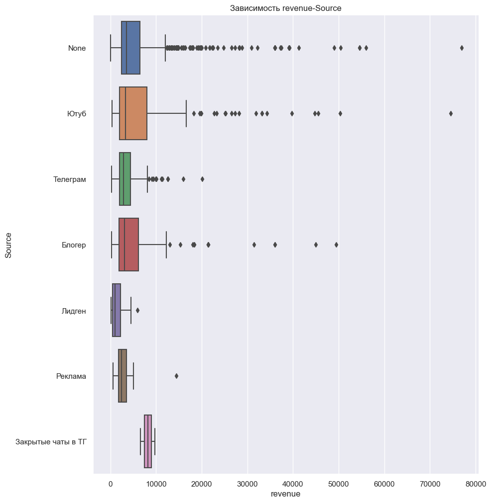

```python
sns.boxplot(data=df, x='revenue', y = 'Source',   orient="h").set(title='Зависимость revenue-Source');
```

В основном источники продают продукты с доходностью до 10 000, блогы и ютуб и неизвестные источники привлекают к покупке наиболее дорогих продуктов (дороже 30 000)

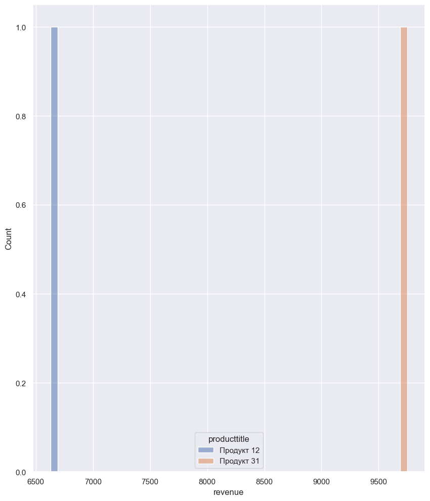

```python
sns.histplot(data=df[df['Source']=='Закрытые чаты в ТГ'], x = 'revenue', hue='producttitle',kde=True, bins=50);
```

В закрытых ТГ каналах продали всего 2 продукта по одному разу, их стоимость выше средней

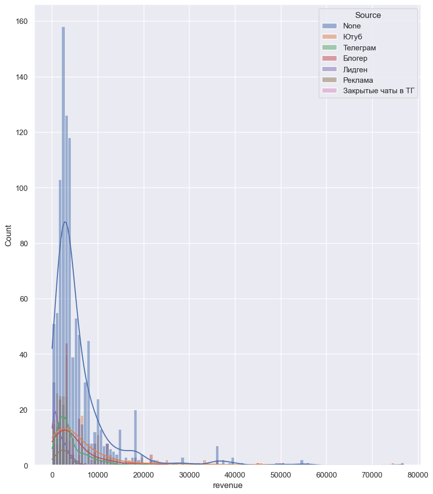

```python
sns.histplot(data=df, x = 'revenue', hue='Source',kde=True);
```

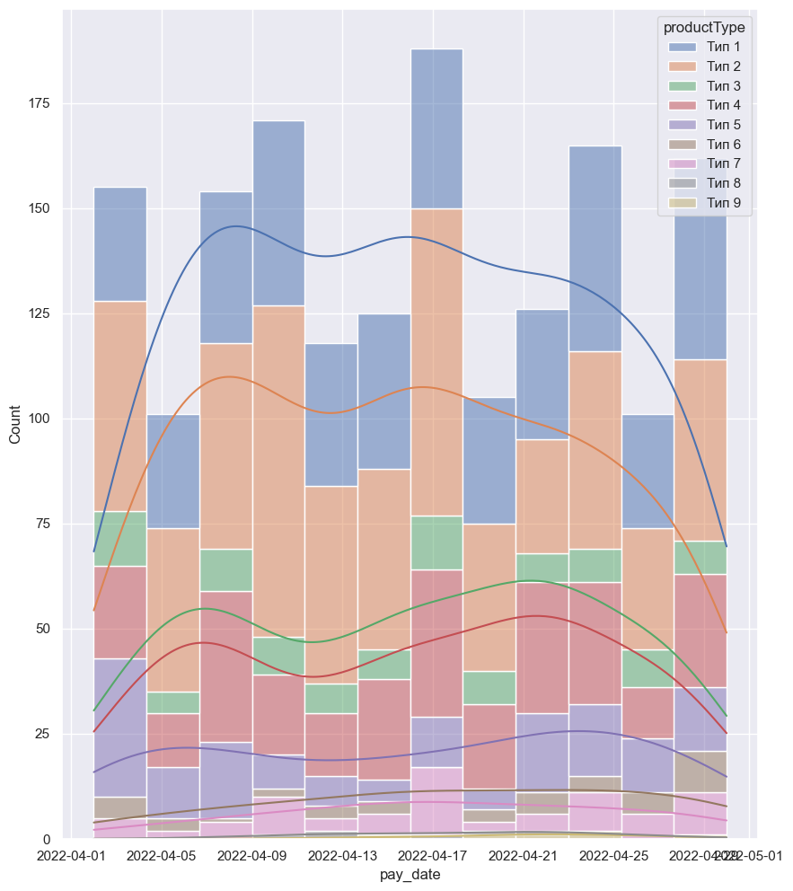

```python
sns.histplot(data=df, x = 'pay_date', hue='productType',kde=True, multiple='stack');
```

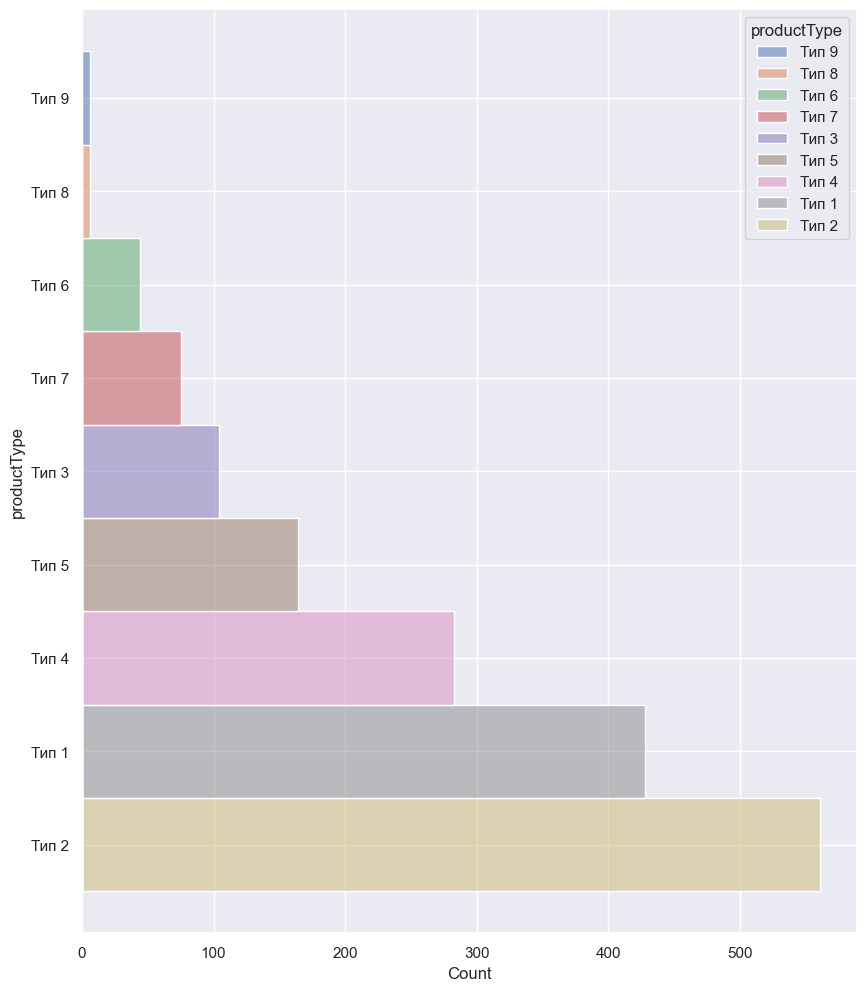

```python
sns.histplot(
    df.sort_values(by = 'type_count'), y="productType", hue="productType", legend=True
)
```

- тип 9 и 8 наиболее отстающие
- тип 1,2 наиболее популярные

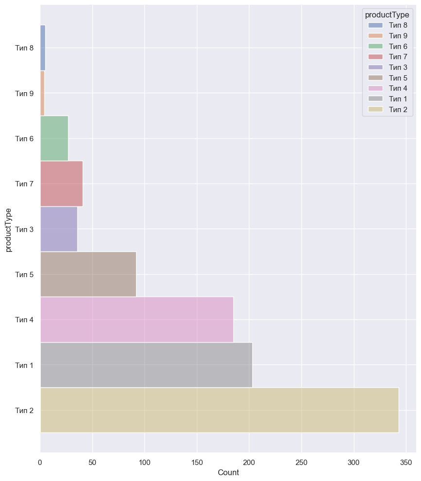

```python
sns.histplot(
    df[df['user_type'] == 'old'].sort_values(by = 'type_count'), y="productType", hue="productType", legend=True
)
```

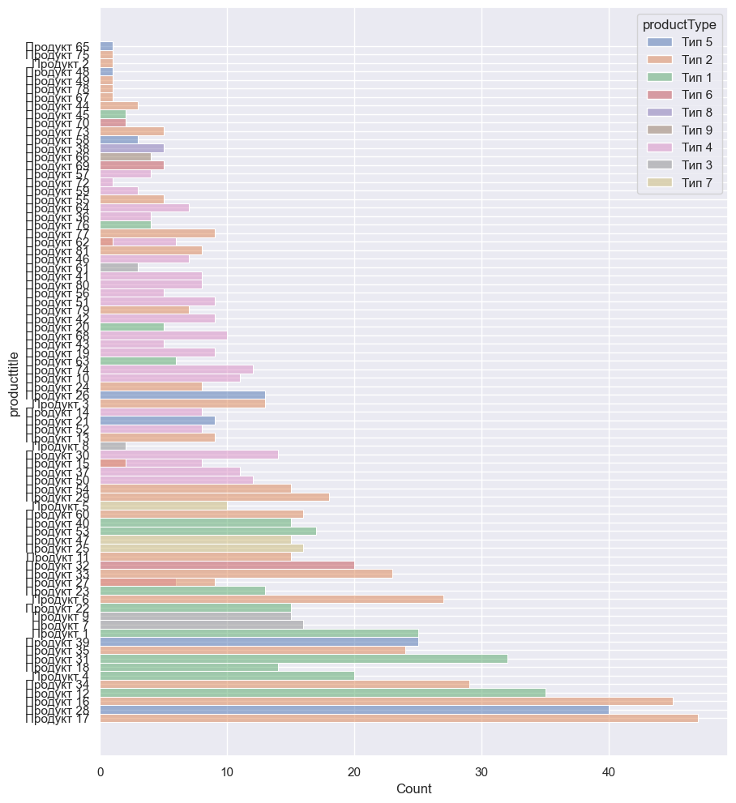

```python
sns.histplot(
    df[df['user_type'] == 'old'].sort_values(by = 'prod_count'), y="producttitle", hue="productType", legend=True
)
```

среди старых пользователей наиболее популярен тип 2

- продукты 12,16,28,17 наиболее популярны у старых пользователей
- продукты 65,75,2,48,49,78,67 наименее популярны у старых пользователей

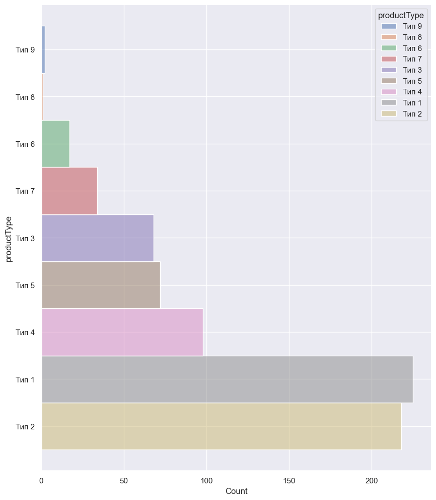

```python
sns.histplot(
    df[df['user_type'] == 'new'].sort_values(by = 'type_count'), y="productType", hue="productType", legend=True
)
```

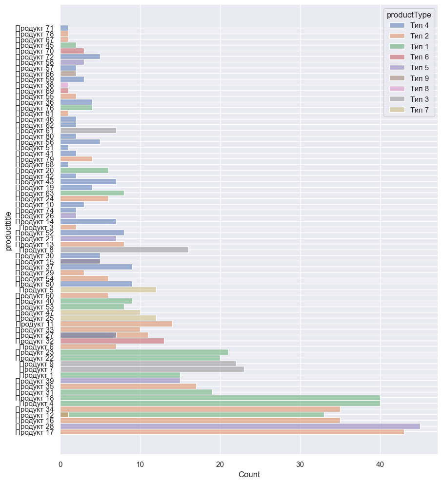

```python
sns.histplot(
    df[df['user_type'] == 'new'].sort_values(by = 'prod_count'), y="producttitle", hue="productType", legend=True
)
```

среди новых пользователей наиболее популярен тип 1,2

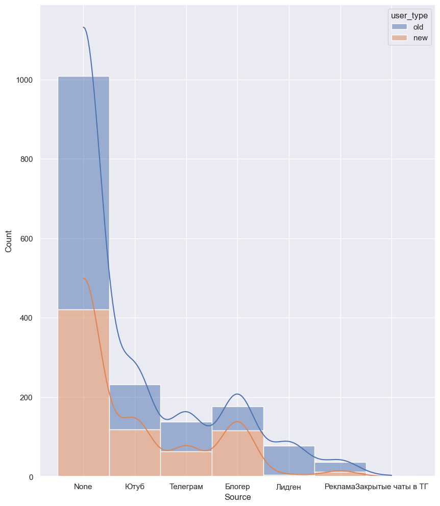

```python
sns.histplot(data = df, x = 'Source', hue='user_type', kde= True, multiple = 'stack')
```

по всем каналам кроме "блогер" большинство пользователей -старые

```python
num = set([65,75,2,48,49,78,67,71,78,67])
```

```python
prod_num = []
for i in num:
    a = 'Продукт ' + str(i)
    print(a)
    prod_num.append(a)
```

```
Продукт 65
Продукт 2
Продукт 67
Продукт 71
Продукт 75
Продукт 78
Продукт 48
Продукт 49
```

```python
prod_num
```

```
['Продукт 65',
 'Продукт 2',
 'Продукт 67',
 'Продукт 71',
 'Продукт 75',
 'Продукт 78',
 'Продукт 48',
 'Продукт 49']
```

```python
df_min = df[df['producttitle'].isin(prod_num)]
```

```python
df_min
```

|  | pay_date | producttitle | productType | revenue | paymenttype | Source | user_type | prod_count | type_count |
| --- | --- | --- | --- | --- | --- | --- | --- | --- | --- |
| 220 | 2022-04-06 | Продукт 48 | Тип 5 | 5940 | покупка | None | old | 1 | 164 |
| 418 | 2022-04-09 | Продукт 75 | Тип 2 | 1950 | покупка | None | old | 1 | 561 |
| 530 | 2022-04-10 | Продукт 78 | Тип 2 | 3440 | покупка | None | old | 2 | 561 |
| 802 | 2022-04-15 | Продукт 71 | Тип 4 | 2480 | покупка | None | new | 1 | 283 |
| 1009 | 2022-04-18 | Продукт 78 | Тип 2 | 3010 | покупка | None | new | 2 | 561 |
| 1095 | 2022-04-20 | Продукт 49 | Тип 2 | 13860 | покупка | None | old | 1 | 561 |
| 1097 | 2022-04-20 | Продукт 65 | Тип 5 | 6860 | покупка | None | old | 1 | 164 |
| 1113 | 2022-04-20 | Продукт 2 | Тип 2 | 1550 | покупка | None | old | 1 | 561 |
| 1638 | 2022-04-30 | Продукт 67 | Тип 2 | 37200 | покупка | None | new | 2 | 561 |
| 1639 | 2022-04-30 | Продукт 67 | Тип 2 | 7440 | покупка | None | old | 2 | 561 |

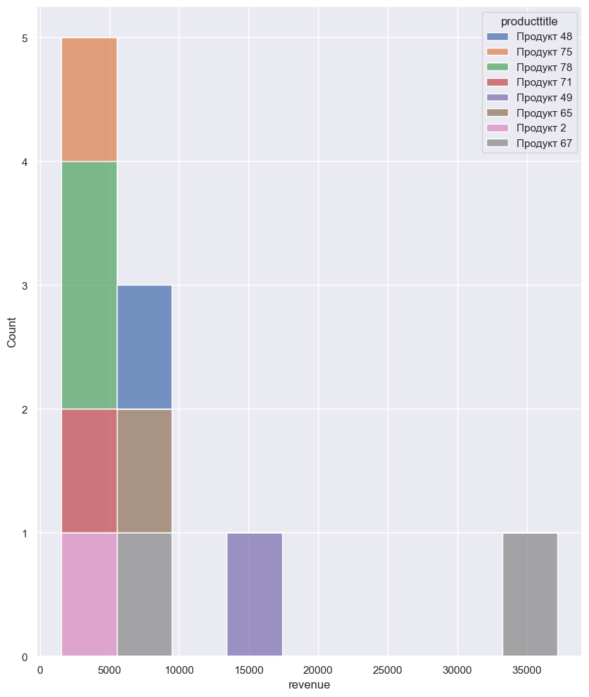

```python
sns.histplot(data = df_min, x = 'revenue', hue='producttitle',  multiple = 'stack')
```

продукт 49 и 67 имеют относительно высокое revenue, возможно низкое значение покупок нормальна для такого типа

с остальными продуктами надо разбираться, в чем причина тиких низких продаж при относительной дешевизне

```python
df_type_max = df[(df['productType'] == 'Тип 2') | (df['productType'] == 'Тип 1')]
```

```python
df_type_max
```

|  | pay_date | producttitle | productType | revenue | paymenttype | Source | user_type | prod_count | type_count |
| --- | --- | --- | --- | --- | --- | --- | --- | --- | --- |
| 0 | 2022-04-02 | Продукт 1 | Тип 1 | 1530 | покупка | None | old | 40 | 428 |
| 1 | 2022-04-02 | Продукт 4 | Тип 1 | 3315 | покупка | Ютуб | new | 60 | 428 |
| 2 | 2022-04-02 | Продукт 6 | Тип 2 | 7170 | покупка | None | old | 34 | 561 |
| 7 | 2022-04-02 | Продукт 12 | Тип 1 | 7140 | покупка | None | new | 69 | 428 |
| 8 | 2022-04-02 | Продукт 12 | Тип 1 | 1530 | покупка | None | old | 69 | 428 |
| ... | ... | ... | ... | ... | ... | ... | ... | ... | ... |
| 1664 | 2022-04-30 | Продукт 35 | Тип 2 | 300 | покупка | None | old | 41 | 561 |
| 1665 | 2022-04-30 | Продукт 35 | Тип 2 | 31850 | покупка | Ютуб | new | 41 | 561 |
| 1666 | 2022-04-30 | Продукт 35 | Тип 2 | 12600 | покупка | Ютуб | old | 41 | 561 |
| 1667 | 2022-04-30 | Продукт 35 | Тип 2 | 2275 | покупка | Телеграм | old | 41 | 561 |
| 1668 | 2022-04-30 | Продукт 44 | Тип 2 | 2480 | покупка | None | old | 3 | 561 |

989 rows × 9 columns

```python
print(f'Тип 1 и 2, процент от всего датасета составляет: {round(100*(len(df_type_max)/len(df)),2)}% ')
```

```
Тип 1 и 2, процент от всего датасета составляет: 59.19%
```

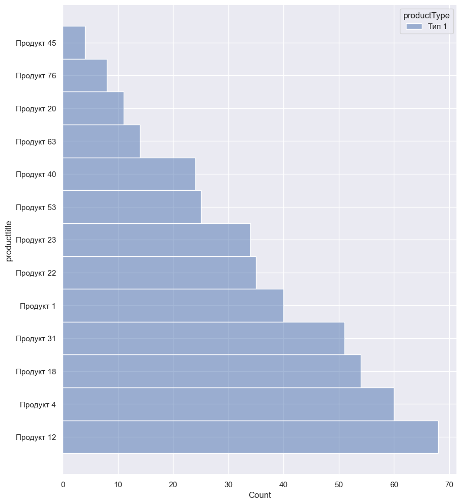

```python
sns.histplot(
    df_type_max[df_type_max['productType']=='Тип 1'].sort_values(by = 'prod_count'), y="producttitle", hue="productType", legend=True
)
```

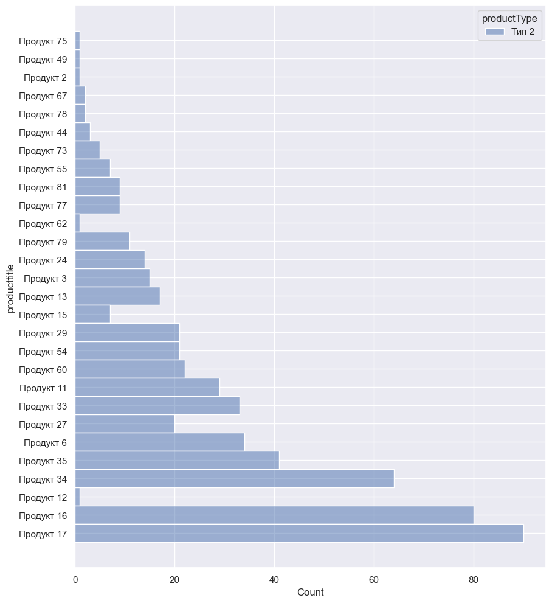

```python
sns.histplot(
    df_type_max[df_type_max['productType']=='Тип 2'].sort_values(by = 'prod_count'), y="producttitle", hue="productType", legend=True
)
```

```python
df_type_max['producttitle'].value_counts().tail(14)
```

```
Продукт 81    9
Продукт 77    9
Продукт 76    8
Продукт 15    7
Продукт 55    7
Продукт 73    5
Продукт 45    4
Продукт 44    3
Продукт 78    2
Продукт 67    2
Продукт 75    1
Продукт 62    1
Продукт 49    1
Продукт 2     1
Name: producttitle, dtype: int64
```

```python
df_type_max
```

|  | pay_date | producttitle | productType | revenue | paymenttype | Source | user_type | prod_count | type_count |
| --- | --- | --- | --- | --- | --- | --- | --- | --- | --- |
| 0 | 2022-04-02 | Продукт 1 | Тип 1 | 1530 | покупка | None | old | 40 | 428 |
| 1 | 2022-04-02 | Продукт 4 | Тип 1 | 3315 | покупка | Ютуб | new | 60 | 428 |
| 2 | 2022-04-02 | Продукт 6 | Тип 2 | 7170 | покупка | None | old | 34 | 561 |
| 7 | 2022-04-02 | Продукт 12 | Тип 1 | 7140 | покупка | None | new | 69 | 428 |
| 8 | 2022-04-02 | Продукт 12 | Тип 1 | 1530 | покупка | None | old | 69 | 428 |
| ... | ... | ... | ... | ... | ... | ... | ... | ... | ... |
| 1664 | 2022-04-30 | Продукт 35 | Тип 2 | 300 | покупка | None | old | 41 | 561 |
| 1665 | 2022-04-30 | Продукт 35 | Тип 2 | 31850 | покупка | Ютуб | new | 41 | 561 |
| 1666 | 2022-04-30 | Продукт 35 | Тип 2 | 12600 | покупка | Ютуб | old | 41 | 561 |
| 1667 | 2022-04-30 | Продукт 35 | Тип 2 | 2275 | покупка | Телеграм | old | 41 | 561 |
| 1668 | 2022-04-30 | Продукт 44 | Тип 2 | 2480 | покупка | None | old | 3 | 561 |

989 rows × 9 columns

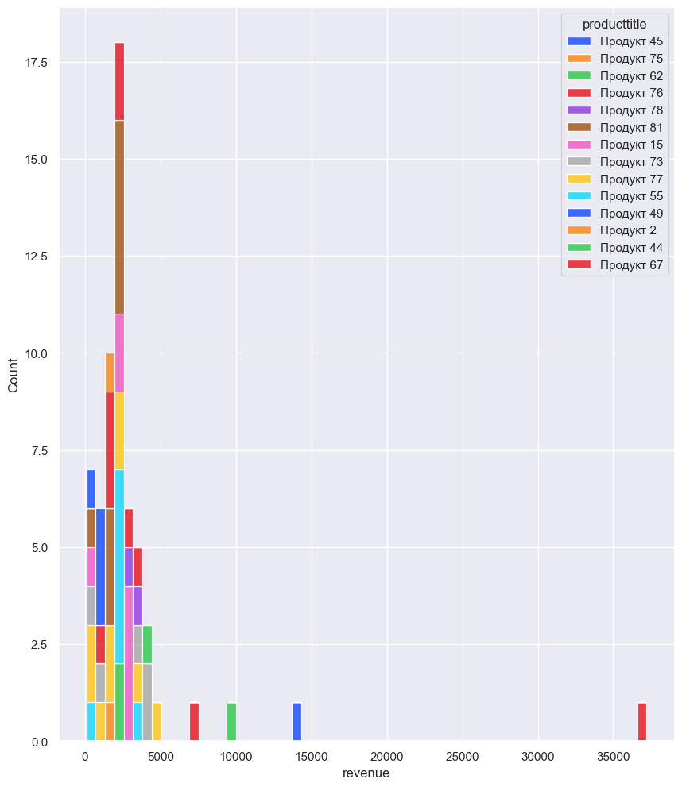

```python
sns.histplot(data = df_type_max[df_type_max['producttitle'].isin(df_type_max['producttitle'].value_counts().tail(14).index)],\
             x = 'revenue', hue='producttitle',  multiple = 'stack', palette='bright')
```

Все представленные выше продукты относятся к самым популярным за месяц типам. Все кроме 67 и 49 продукта, из за относительно небольшого revenue потенциально должны пользоваться спросом.

### Какой продукт покупают чаще всего старые пользователи?

```python
sns.histplot(
    df[df['user_type'] == 'old'].sort_values(by = 'prod_count'), y="producttitle", hue="productType", legend=True
)
```

[output not shown]

### Какие пользователи приносят больше выручки в телеграме — старые или новые?

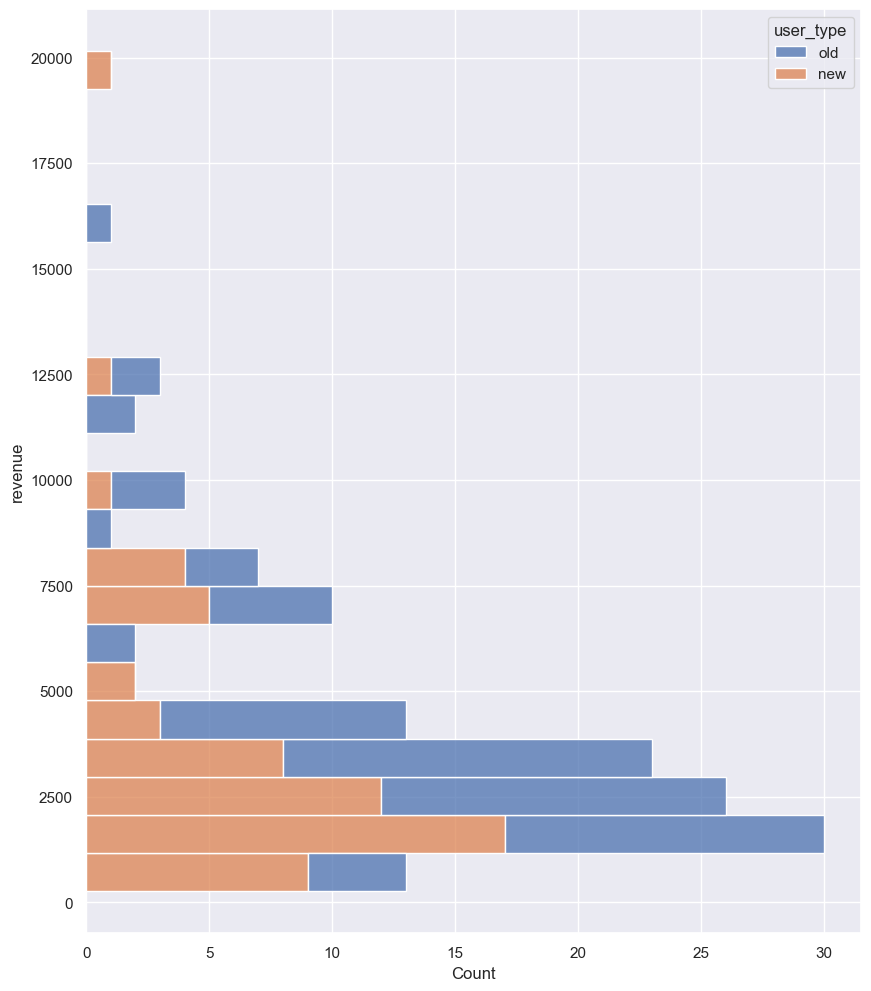

```python
sns.histplot(
    df[df['Source'] == 'Телеграм'], y="revenue", hue="user_type", legend=True, multiple='stack'
)
```

```python
df[df['Source'] == 'Телеграм'].pivot_table(index='user_type', values = 'revenue', aggfunc='sum')
```

| user_type | revenue |
| --- | --- |
| new | 220910 |
| old | 324387 |

### Вывод

В ходе исследования :

- отобрали самые популярные типы продуктов,
- в них нашли самые редко продаваемые,
- исключили те, у которых высокое revenue(из условий не ясно точно, но я предполагаю что это редкий продукт который окупается своей ценой).

1) **Считаю что нужно делать упор на следующих продуктах:**

- 'Продукт 81',
- 'Продукт 77',
- 'Продукт 76',
- 'Продукт 15',
- 'Продукт 55',
- 'Продукт 73',
- 'Продукт 45',
- 'Продукт 44',
- 'Продукт 78',
- 'Продукт 75',
- 'Продукт 62',
- 'Продукт 2'

2) Старые пользователи чаще всего покупают продукт 17

3) Больше прибыли приносят старые пользователи из телеграм (324 387), это на 103 477 больше чем новые пользователи.

*при условии что в источнике None нет телеграма*

## ЗАДАНИЕ 3

Мы хотим посмотреть, сколько у нас новых клиентов из России, которые пришли к нам из ютуба и купили 2 и больше курсов за последний месяц. Напиши SQL запрос, по которому ты получишь все данные для ответа на этот вопрос. Метрики называй, как хочешь)

```python
# пишем запрос для вывода необходимых строк
'''
SELECT user_id, COUNT(order)
FROM table as t
WHERE country = 'Russia'
        AND Source = 'YouTube'
        AND user_type = 'new'
        AND date >= DATEADD(MONTH, -1, GETDATE())
GROUP BY user_id
HAVING COUNT(order)>=2
'''
```

```
"\nSELECT user_id, COUNT(order)\nFROM table as t\nWHERE country = 'Russia'\n        AND Source = 'YouTube'\n        AND user_type = 'new'\n        AND date >= DATEADD(MONTH, -1, GETDATE())\nGROUP BY user_id    \nHAVING COUNT(order)>=2\n"
```

```python
# В задании сказано что нужно посчитать количество клиентов по уловиям.
# В результате выведем число
'''SELECT COUNT(*) AS ysers_count
FROM (
    SELECT user_id
    FROM table AS t
    WHERE country = 'Russia'
        AND Source = 'YouTube'
        AND user_type = 'new'
        AND date >= DATEADD(MONTH, -1, GETDATE())
    GROUP BY user_id
    HAVING COUNT(*) >= 2
) AS subquery;'''
```

```
"SELECT COUNT(*) AS ysers_count\nFROM (\n    SELECT user_id\n    FROM table AS t\n    WHERE country = 'Russia'\n        AND Source = 'YouTube'\n        AND user_type = 'new'\n        AND date >= DATEADD(MONTH, -1, GETDATE())\n    GROUP BY user_id    \n    HAVING COUNT(*) >= 2\n) AS subquery;"
```